# Math208-A2

MATH 208 - Assignment 2 - Christopher Zheng - 206760794

Question 1:

```r
#install.packages("fivethirtyeight")
library(fivethirtyeight)
library(tidyverse)
```

```r
library(ggplot2)

df <- tbl_df(biopics)
```

1. Using the plot of your choice, assess whether the total number of biopics released per year has increased over time based on the data collected from the IMDB movie database.

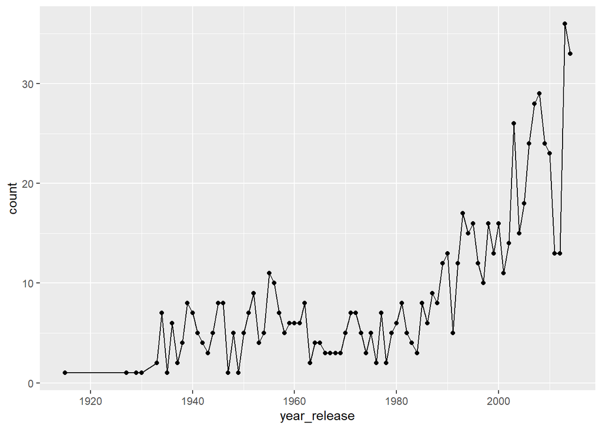

```r
df_per_year <- df %>% group_by(year_release) %>% summarise(count=n())

ggplot(df_per_year,aes(x=year_release,y=count,group=1)) +
  geom_point() + geom_line(stat="summary",fun.y=mean)
```

```r
#In conlcusion, the total number of biopics released per year has increased over time based on the timeline.
```

2. Produce a stacked barplot similar to the barplot in the original article showing the relative numbers of male and female subjects over time (Note the figures will not exactly be the same as the data in the article figures is not the same as in the dataset).

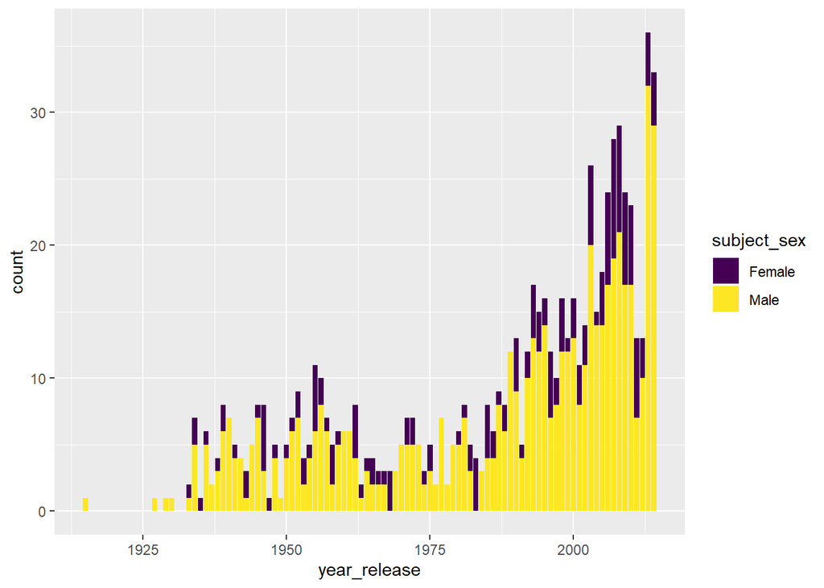

```r
df_per_year <- df %>% group_by(year_release) %>% mutate(count=n())

ggplot(df_per_year,aes(x=year_release,fill=subject_sex)) +
  geom_bar() + scale_fill_viridis_d()
```

```r
head(df_per_year)
```

```
## # A tibble: 6 x 15
## # Groups:   year_release [6]
##   title site  country year_release box_office director number_of_subje~
##   <chr> <chr> <chr>          <int>      <dbl> <chr>               <int>
## 1 10 R~ tt00~ UK              1971         NA Richard~                1
## 2 12 Y~ tt20~ US/UK           2013   56700000 Steve M~                1
## 3 127 ~ tt15~ US/UK           2010   18300000 Danny B~                1
## 4 1987  tt28~ Canada          2014         NA Ricardo~                1
## 5 20 D~ tt01~ US              1998     537000 Myles B~                1
## 6 21    tt04~ US              2008   81200000 Robert ~                1
## # ... with 8 more variables: subject <chr>, type_of_subject <chr>,
## #   race_known <chr>, subject_race <chr>, person_of_color <lgl>,
## #   subject_sex <chr>, lead_actor_actress <chr>, count <int>
```

3. Produce a stacked barplot similar to the barplot in the original article showing the relative numbers of white subjects, subjects who are persons of color, and unknown race subjects over time. (Mote the figures will not exactly be the same as the data in the article figures is not the same as in the dataset).

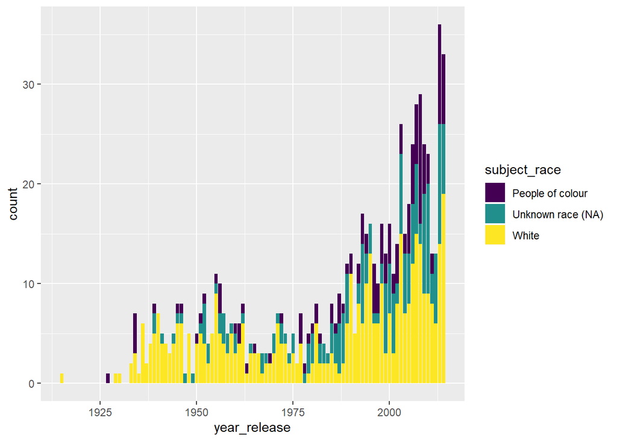

```r
df_per_year <- df %>% group_by(year_release) %>% mutate(count=n()) %>%
  mutate(subject_race = ifelse(is.na(subject_race),"Unknown race (NA)",ifelse(subject_race=="White",subject_race,"People of colour")) )
#df_per_year
ggplot(df_per_year,aes(x=year_release,fill=subject_race)) +
  geom_bar() + scale_fill_viridis_d()
```

4. Based on a mosaic plot (collapsing over year of release), which sex / white-nonwhite-NA group is the most underrepresented in biopics based on number of subjets?

[figure not shown]

```r
library(ggmosaic)
df_per_year <- df %>% group_by(year_release) %>% mutate(count=n()) %>%
  mutate(subject_race = ifelse(is.na(subject_race),"Unknown race (NA)",ifelse(subject_race=="White",subject_race,"People of colour")) )


ggplot(df_per_year) +
  geom_mosaic(aes(x=product(year_release), fill=interaction(subject_sex,subject_race)))+
  xlab("Year") + ylab("")
```

```r
# Based on the mosaic plot, females who are people of colours are the most underrepresented.
```

5. Produce a summary table containing counts and proportions of biopic subjects per year for each sex/white-nonwehite-NA factor combination.

```r
library(dplyr)

df_per_year <- df %>% group_by(year_release) %>% mutate(count=n()) %>%
  mutate(subject_race = ifelse(is.na(subject_race),"Unknown race (NA)",ifelse(subject_race=="White",subject_race,"People of colour")) ) %>%
  select(year_release,subject_race,subject_sex,count)
#df_per_year
df_summary <- df_per_year %>% group_by(year_release,subject_sex,subject_race) %>% mutate(number = n(),proportion=number/count)



df_summary <- df_summary[order(df_summary$year_release),] %>% unique(.) %>% select(year_release,subject_sex,subject_race,number,proportion)
df_summary
```

```
## # A tibble: 281 x 5
## # Groups:   year_release, subject_sex, subject_race [281]
##    year_release subject_sex subject_race     number proportion
##           <int> <chr>       <chr>             <int>      <dbl>
##  1         1915 Male        White                 1      1
##  2         1927 Male        People of colour      1      1
##  3         1929 Male        White                 1      1
##  4         1930 Male        White                 1      1
##  5         1933 Female      White                 1      0.5
##  6         1933 Male        White                 1      0.5
##  7         1934 Female      People of colour      2      0.286
##  8         1934 Male        White                 3      0.429
##  9         1934 Male        People of colour      2      0.286
## 10         1935 Female      White                 1      1
## # ... with 271 more rows
```

6. Create (i) a line plot showing the counts of these groups over time and (ii) a line plot showing the relative proportions of subjects over time. Would you infer from these plots that the imbalance is improving over time or not? Explain your answer.

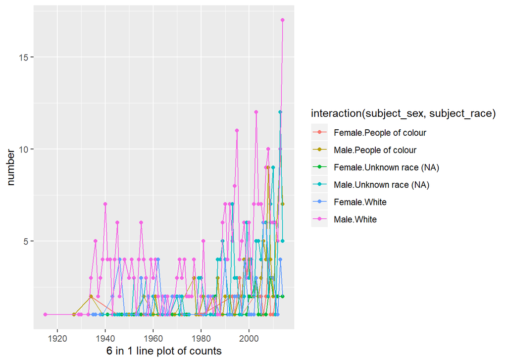

```r
#df_summary

ggplot(df_summary,aes(x=year_release,y=number,fill=interaction(subject_sex,subject_race))) +
  geom_point(aes(color=interaction(subject_sex,subject_race))) + geom_line(stat="summary",fun.y=mean,aes(color=interaction(subject_sex,subject_race))) +
  xlab("6 in 1 line plot of counts")
```

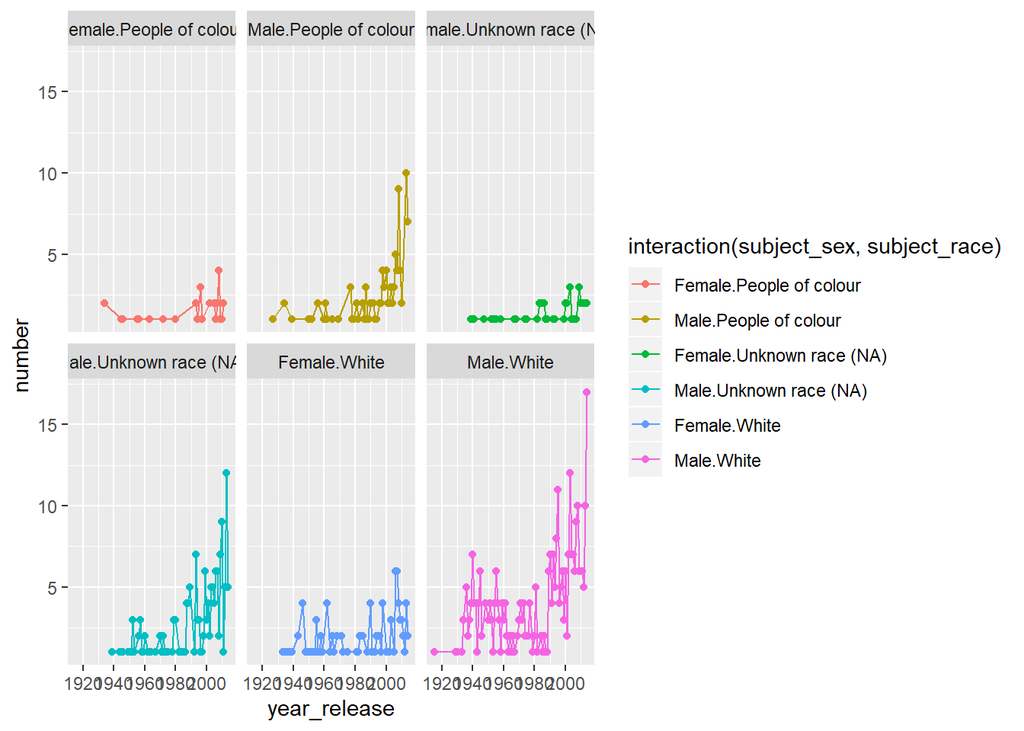

```r
ggplot(df_summary,aes(x=year_release,y=number,fill=interaction(subject_sex,subject_race))) +
  geom_point(aes(color=interaction(subject_sex,subject_race))) + geom_line(stat="summary",fun.y=mean,aes(color=interaction(subject_sex,subject_race))) + facet_wrap(~interaction(subject_sex,subject_race))
```

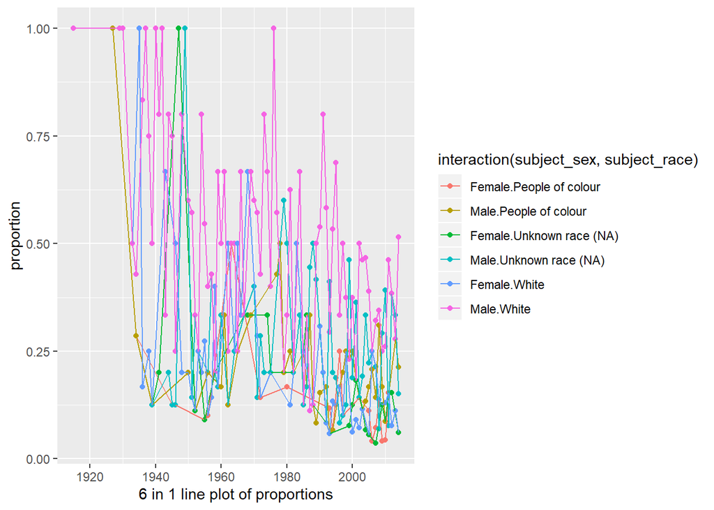

```r
ggplot(df_summary,aes(x=year_release,y=proportion,fill=interaction(subject_sex,subject_race))) +
  geom_point(aes(color=interaction(subject_sex,subject_race))) + geom_line(stat="summary",fun.y=mean,aes(color=interaction(subject_sex,subject_race))) +
  xlab("6 in 1 line plot of proportions")
```